# EDA

```python
import pandas as pd
import numpy as np
```

```python
df = pd.read_csv('starcraft_player_data.csv')
```

```python
df
```

|  | GameID | LeagueIndex | Age | HoursPerWeek | TotalHours | APM | SelectByHotkeys | AssignToHotkeys | UniqueHotkeys | MinimapAttacks | MinimapRightClicks | NumberOfPACs | GapBetweenPACs | ActionLatency | ActionsInPAC | TotalMapExplored | WorkersMade | UniqueUnitsMade | ComplexUnitsMade | ComplexAbilitiesUsed |
| --- | --- | --- | --- | --- | --- | --- | --- | --- | --- | --- | --- | --- | --- | --- | --- | --- | --- | --- | --- | --- |
| 0 | 52 | 5 | 27 | 10 | 3000 | 143.7180 | 0.003515 | 0.000220 | 7 | 0.000110 | 0.000392 | 0.004849 | 32.6677 | 40.8673 | 4.7508 | 28 | 0.001397 | 6 | 0.000000 | 0.000000 |
| 1 | 55 | 5 | 23 | 10 | 5000 | 129.2322 | 0.003304 | 0.000259 | 4 | 0.000294 | 0.000432 | 0.004307 | 32.9194 | 42.3454 | 4.8434 | 22 | 0.001193 | 5 | 0.000000 | 0.000208 |
| 2 | 56 | 4 | 30 | 10 | 200 | 69.9612 | 0.001101 | 0.000336 | 4 | 0.000294 | 0.000461 | 0.002926 | 44.6475 | 75.3548 | 4.0430 | 22 | 0.000745 | 6 | 0.000000 | 0.000189 |
| 3 | 57 | 3 | 19 | 20 | 400 | 107.6016 | 0.001034 | 0.000213 | 1 | 0.000053 | 0.000543 | 0.003783 | 29.2203 | 53.7352 | 4.9155 | 19 | 0.000426 | 7 | 0.000000 | 0.000384 |
| 4 | 58 | 3 | 32 | 10 | 500 | 122.8908 | 0.001136 | 0.000327 | 2 | 0.000000 | 0.001329 | 0.002368 | 22.6885 | 62.0813 | 9.3740 | 15 | 0.001174 | 4 | 0.000000 | 0.000019 |
| ... | ... | ... | ... | ... | ... | ... | ... | ... | ... | ... | ... | ... | ... | ... | ... | ... | ... | ... | ... | ... |
| 3390 | 10089 | 8 | ? | ? | ? | 259.6296 | 0.020425 | 0.000743 | 9 | 0.000621 | 0.000146 | 0.004555 | 18.6059 | 42.8342 | 6.2754 | 46 | 0.000877 | 5 | 0.000000 | 0.000000 |
| 3391 | 10090 | 8 | ? | ? | ? | 314.6700 | 0.028043 | 0.001157 | 10 | 0.000246 | 0.001083 | 0.004259 | 14.3023 | 36.1156 | 7.1965 | 16 | 0.000788 | 4 | 0.000000 | 0.000000 |
| 3392 | 10092 | 8 | ? | ? | ? | 299.4282 | 0.028341 | 0.000860 | 7 | 0.000338 | 0.000169 | 0.004439 | 12.4028 | 39.5156 | 6.3979 | 19 | 0.001260 | 4 | 0.000000 | 0.000000 |
| 3393 | 10094 | 8 | ? | ? | ? | 375.8664 | 0.036436 | 0.000594 | 5 | 0.000204 | 0.000780 | 0.004346 | 11.6910 | 34.8547 | 7.9615 | 15 | 0.000613 | 6 | 0.000000 | 0.000631 |
| 3394 | 10095 | 8 | ? | ? | ? | 348.3576 | 0.029855 | 0.000811 | 4 | 0.000224 | 0.001315 | 0.005566 | 20.0537 | 33.5142 | 6.3719 | 27 | 0.001566 | 7 | 0.000457 | 0.000895 |

3395 rows × 20 columns

```python
# Check null values in each column
df.isnull().sum()
```

```
GameID                  0
LeagueIndex             0
Age                     0
HoursPerWeek            0
TotalHours              0
APM                     0
SelectByHotkeys         0
AssignToHotkeys         0
UniqueHotkeys           0
MinimapAttacks          0
MinimapRightClicks      0
NumberOfPACs            0
GapBetweenPACs          0
ActionLatency           0
ActionsInPAC            0
TotalMapExplored        0
WorkersMade             0
UniqueUnitsMade         0
ComplexUnitsMade        0
ComplexAbilitiesUsed    0
dtype: int64
```

```python
# Check the data type in each column
df.dtypes
```

```
GameID                    int64
LeagueIndex               int64
Age                      object
HoursPerWeek             object
TotalHours               object
APM                     float64
SelectByHotkeys         float64
AssignToHotkeys         float64
UniqueHotkeys             int64
MinimapAttacks          float64
MinimapRightClicks      float64
NumberOfPACs            float64
GapBetweenPACs          float64
ActionLatency           float64
ActionsInPAC            float64
TotalMapExplored          int64
WorkersMade             float64
UniqueUnitsMade           int64
ComplexUnitsMade        float64
ComplexAbilitiesUsed    float64
dtype: object
```

```python
# Remove rows containing non-numeric values
for column in df.columns:
    df = df[pd.to_numeric(df[column], errors='coerce').notnull()]
df
```

|  | GameID | LeagueIndex | Age | HoursPerWeek | TotalHours | APM | SelectByHotkeys | AssignToHotkeys | UniqueHotkeys | MinimapAttacks | MinimapRightClicks | NumberOfPACs | GapBetweenPACs | ActionLatency | ActionsInPAC | TotalMapExplored | WorkersMade | UniqueUnitsMade | ComplexUnitsMade | ComplexAbilitiesUsed |
| --- | --- | --- | --- | --- | --- | --- | --- | --- | --- | --- | --- | --- | --- | --- | --- | --- | --- | --- | --- | --- |
| 0 | 52 | 5 | 27 | 10 | 3000 | 143.7180 | 0.003515 | 0.000220 | 7 | 0.000110 | 0.000392 | 0.004849 | 32.6677 | 40.8673 | 4.7508 | 28 | 0.001397 | 6 | 0.0 | 0.000000 |
| 1 | 55 | 5 | 23 | 10 | 5000 | 129.2322 | 0.003304 | 0.000259 | 4 | 0.000294 | 0.000432 | 0.004307 | 32.9194 | 42.3454 | 4.8434 | 22 | 0.001193 | 5 | 0.0 | 0.000208 |
| 2 | 56 | 4 | 30 | 10 | 200 | 69.9612 | 0.001101 | 0.000336 | 4 | 0.000294 | 0.000461 | 0.002926 | 44.6475 | 75.3548 | 4.0430 | 22 | 0.000745 | 6 | 0.0 | 0.000189 |
| 3 | 57 | 3 | 19 | 20 | 400 | 107.6016 | 0.001034 | 0.000213 | 1 | 0.000053 | 0.000543 | 0.003783 | 29.2203 | 53.7352 | 4.9155 | 19 | 0.000426 | 7 | 0.0 | 0.000384 |
| 4 | 58 | 3 | 32 | 10 | 500 | 122.8908 | 0.001136 | 0.000327 | 2 | 0.000000 | 0.001329 | 0.002368 | 22.6885 | 62.0813 | 9.3740 | 15 | 0.001174 | 4 | 0.0 | 0.000019 |
| ... | ... | ... | ... | ... | ... | ... | ... | ... | ... | ... | ... | ... | ... | ... | ... | ... | ... | ... | ... | ... |
| 3335 | 9261 | 4 | 20 | 8 | 400 | 158.1390 | 0.013829 | 0.000504 | 7 | 0.000217 | 0.000313 | 0.003583 | 36.3990 | 66.2718 | 4.5097 | 30 | 0.001035 | 7 | 0.0 | 0.000287 |
| 3336 | 9264 | 5 | 16 | 56 | 1500 | 186.1320 | 0.006951 | 0.000360 | 6 | 0.000083 | 0.000166 | 0.005414 | 22.8615 | 34.7417 | 4.9309 | 38 | 0.001343 | 7 | 0.0 | 0.000388 |
| 3337 | 9265 | 4 | 21 | 8 | 100 | 121.6992 | 0.002956 | 0.000241 | 8 | 0.000055 | 0.000208 | 0.003690 | 35.5833 | 57.9585 | 5.4154 | 23 | 0.002014 | 7 | 0.0 | 0.000000 |
| 3338 | 9270 | 3 | 20 | 28 | 400 | 134.2848 | 0.005424 | 0.000182 | 5 | 0.000000 | 0.000480 | 0.003205 | 18.2927 | 62.4615 | 6.0202 | 18 | 0.000934 | 5 | 0.0 | 0.000000 |
| 3339 | 9271 | 4 | 22 | 6 | 400 | 88.8246 | 0.000844 | 0.000108 | 2 | 0.000000 | 0.000341 | 0.003099 | 45.1512 | 63.4435 | 5.1913 | 20 | 0.000476 | 8 | 0.0 | 0.000054 |

3338 rows × 20 columns

```python
# Convert object to int64 for model building
df['Age'] = df['Age'].astype('int64')
df['HoursPerWeek'] = df['HoursPerWeek'].astype('int64')
df['TotalHours'] = df['TotalHours'].astype('int64')
```

```python
# Drop GameID
df = df.drop('GameID', axis=1)
```

### The data set has no missing or null values. However, there are columns containing non-numeric values. Since all features are supposed to contain either integers or continuous numeric values, I removed rows that contain non-numeric values.

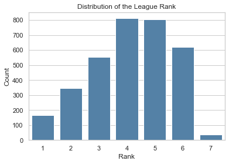

```python
# Find the distribution of the league rank
import seaborn as sns
import matplotlib.pyplot as plt

league_counts = df['LeagueIndex'].value_counts().sort_index()
sns.set(style="whitegrid")
sns.barplot(x=league_counts.index, y=league_counts.values, color='steelblue')
plt.xlabel('Rank')
plt.ylabel('Count')
plt.title('Distribution of the League Rank')
plt.show()
```

```python
# Count the number of the differnt ranks
index_counts = df['LeagueIndex'].value_counts()
print(index_counts)
```

```
4    811
5    804
6    621
3    553
2    347
1    167
7     35
Name: LeagueIndex, dtype: int64
```

### The distribution of our target variable, LeagueIndex, shows that our data set is highly imbalanced. In other words, significantly more players are ranked under Gold, Platinum, Diamond, and Master while less players are ranked under Bronze, Silver, or GrandMaster. What's more, no player is ranked under Professional in the dataset, which means the model I build based on this dataset will not provide any support to predict someone who is ranked at Professional.

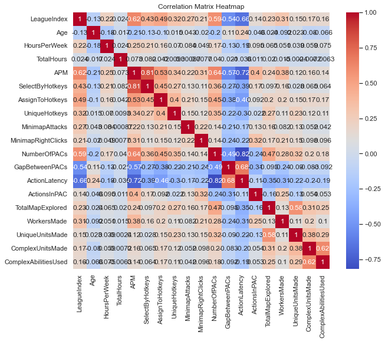

```python
# Check the correlation matrix heat map
import seaborn as sns
import matplotlib.pyplot as plt

correlation_matrix = df.corr()
plt.figure(figsize=(10, 8))
sns.heatmap(correlation_matrix, annot=True, cmap='coolwarm', square=True)
plt.title('Correlation Matrix Heatmap')
plt.show()
```

```python
# Find the top positively correlated features with LeagueIndex
league_index_correlation = correlation_matrix['LeagueIndex']
positively_correlated = league_index_correlation[league_index_correlation > 0]
top_positively_correlated = positively_correlated.sort_values(ascending=False)[1:]
print(top_positively_correlated)
```

```
APM                     0.624171
NumberOfPACs            0.589193
AssignToHotkeys         0.487280
SelectByHotkeys         0.428637
UniqueHotkeys           0.322415
WorkersMade             0.310452
MinimapAttacks          0.270526
TotalMapExplored        0.230347
HoursPerWeek            0.217930
MinimapRightClicks      0.206380
ComplexUnitsMade        0.171190
ComplexAbilitiesUsed    0.156033
UniqueUnitsMade         0.151933
ActionsInPAC            0.140303
TotalHours              0.023884
Name: LeagueIndex, dtype: float64
```

```python
# Find the top negatively correlated features with LeagueIndex
negatively_correlated = league_index_correlation[league_index_correlation < 0]
top_negatively_correlated = negatively_correlated.sort_values(ascending=True)
print(top_negatively_correlated)
```

```
ActionLatency    -0.659940
GapBetweenPACs   -0.537536
Age              -0.127518
Name: LeagueIndex, dtype: float64
```

### The top positively and negatively correlated features with LeagueIndex are shown above. This provides information on which features are more likely to contribute to the prediction of LeagueIndex in the model. The higher the absolute value of the correlation between a feature and LeagueIndex, the greater the likelihood that the feature will play a significant role in predicting LeagueIndex.

### At this point, I would assume APM, NumberOfPACs, ActionLatency, and GapBetweenPACs as more significant features in predicting the rank.

```python
# Pairs of features with top correlation
corr_df = correlation_matrix.stack().reset_index()
corr_df.columns = ['Feature1', 'Feature2', 'Correlation']
corr_df = corr_df[corr_df['Feature1'] != corr_df['Feature2']]
corr_df['AbsCorrelation'] = np.abs(corr_df['Correlation'])
sorted_corr_df = corr_df.sort_values(by='AbsCorrelation', ascending=False)

print(sorted_corr_df.head(40))
```

```
                 Feature1              Feature2  Correlation  AbsCorrelation
202          NumberOfPACs         ActionLatency    -0.817162        0.817162
238         ActionLatency          NumberOfPACs    -0.817162        0.817162
99        SelectByHotkeys                   APM     0.814624        0.814624
81                    APM       SelectByHotkeys     0.814624        0.814624
232         ActionLatency                   APM    -0.722253        0.722253
88                    APM         ActionLatency    -0.722253        0.722253
221        GapBetweenPACs         ActionLatency     0.680483        0.680483
239         ActionLatency        GapBetweenPACs     0.680483        0.680483
228         ActionLatency           LeagueIndex    -0.659940        0.659940
12            LeagueIndex         ActionLatency    -0.659940        0.659940
194          NumberOfPACs                   APM     0.635248        0.635248
86                    APM          NumberOfPACs     0.635248        0.635248
4             LeagueIndex                   APM     0.624171        0.624171
76                    APM           LeagueIndex     0.624171        0.624171
```

[output cut: 26 more lines]

### The pairs of features with top correlation above shows that many features in the dataset is highly correlated, which means it might be necessary for us to combine them through feature engineering or discard one of them, depending on the potential improvement to the model.

### For instance, NumberOfPACs is highly correlated with ActionLatency, and SelectHotkeys is also highly correlated with APM. There are many reasons why this could happen. First of all, since we have limited amount of data, this correlation might happen simply by chance. The correlation will decrease as more data are collected. Secondly, these features are indeed inherently correlated and need to be modified for modeling.

```python
# Feature Engineering
# df['PACLatency'] = df['NumberOfPACs'] * df['ActionLatency']
# df['SelectAction'] = df['APM'] * df['SelectByHotkeys']
# df['PACActions'] = df['NumberOfPACs'] * df['ActionsInPAC']
```

### Above is the feature engineering I will attempt for modeling based on my interpretation on the features.

```python
# Find the number of outliers in each column
import numpy as np

Q1 = df.quantile(0.25)
Q3 = df.quantile(0.75)
IQR = Q3 - Q1
outliers_count = ((df < (Q1 - 1.5 * IQR)) | (df > (Q3 + 1.5 * IQR))).sum()
print(outliers_count)
```

```
LeagueIndex               0
Age                      98
HoursPerWeek            171
TotalHours              169
APM                      74
SelectByHotkeys         261
AssignToHotkeys          44
UniqueHotkeys             0
MinimapAttacks          271
MinimapRightClicks      181
NumberOfPACs             49
GapBetweenPACs          108
ActionLatency            87
ActionsInPAC             85
TotalMapExplored         44
WorkersMade             142
UniqueUnitsMade           4
ComplexUnitsMade        345
ComplexAbilitiesUsed    294
dtype: int64
```

### There are outliers in almost every feature. Some features even have many outliers. However, it might not be reasonable to remove outliers considering that there is only 3338 rows of data, which are expected to applied on predicting 7 ordinal values. Removing outliers of any features might affect the representiveness of the dataset.

# Modeling and Evaluation

```python
# Separate the features and target
X = df.drop('LeagueIndex', axis=1).drop('NumberOfPACs', axis=1).drop('SelectByHotkeys', axis=1)
y = df['LeagueIndex']
```

```python
# Split the data into training and testing sets
from sklearn.model_selection import train_test_split

X_train, X_test, y_train, y_test = train_test_split(X, y, test_size=0.2, random_state=42, stratify=y)
```

### The target variable, LeagueIndex, is already ordinal. Hence, there is no need to encode it before fitting the model.

```python
# Scale the features
from sklearn.preprocessing import StandardScaler

scaler = StandardScaler()
X_train_scaled = scaler.fit_transform(X_train)
X_test_scaled = scaler.transform(X_test)
```

### There is a big difference in the magnitude between features due to different units, so we need to scale the feature data before we fit the model.

```python
# Apply SMOTE to the training set
from imblearn.over_sampling import SMOTE

smote = SMOTE(random_state=42)
X_train_resampled, y_train_resampled = smote.fit_resample(X_train_scaled, y_train)
```

### Since the dataset is imbalanced, we need to apply SMOTE to the training set before we fit the model.

## Model 1: Random Forest

```python
from sklearn.ensemble import RandomForestClassifier
from sklearn.metrics import classification_report

rf = RandomForestClassifier()
rf.fit(X_train_resampled, y_train_resampled)
rf_pred = rf.predict(X_test_scaled)

print(classification_report(y_test, rf_pred))
```

```
              precision    recall  f1-score   support

           1       0.33      0.45      0.38        33
           2       0.27      0.30      0.29        70
           3       0.33      0.38      0.35       111
           4       0.41      0.36      0.39       162
           5       0.45      0.34      0.38       161
           6       0.58      0.70      0.64       124
           7       0.00      0.00      0.00         7

    accuracy                           0.42       668
   macro avg       0.34      0.36      0.35       668
weighted avg       0.41      0.42      0.41       668
```

```python
importance_rf = rf.feature_importances_
feature_importance_rf = pd.DataFrame({'Feature': X.columns, 'Importance': importance_rf})
feature_importance_rf = feature_importance_rf.sort_values(by='Importance', ascending=False)
print(feature_importance_rf.to_string(index=False))
```

```
             Feature  Importance
       ActionLatency    0.125753
                 APM    0.109553
          TotalHours    0.079082
      GapBetweenPACs    0.077726
     AssignToHotkeys    0.077337
      MinimapAttacks    0.064887
         WorkersMade    0.059638
        ActionsInPAC    0.058174
  MinimapRightClicks    0.053374
       UniqueHotkeys    0.052011
        HoursPerWeek    0.049057
    TotalMapExplored    0.047149
                 Age    0.046341
     UniqueUnitsMade    0.041393
ComplexAbilitiesUsed    0.035710
    ComplexUnitsMade    0.022815
```

```python
# Hyperparameter tuning
from sklearn.model_selection import GridSearchCV

param_grid = {
    'n_estimators': [100, 200, 300, 400, 500],
    'max_depth': [None, 10, 20, 30, 40],
    'min_samples_split': [2, 5, 10],
    'min_samples_leaf': [1, 2, 4],
    'bootstrap': [True, False]
}

rf = RandomForestClassifier(random_state=42)

grid_search = GridSearchCV(estimator=rf, param_grid=param_grid, cv=5, n_jobs=-1, verbose=2)


grid_search.fit(X_train_resampled, y_train_resampled)


best_params = grid_search.best_params_
print(f"Best parameters: {best_params}")

best_rf = RandomForestClassifier(**best_params)
best_rf.fit(X_train_resampled, y_train_resampled)

rf_prediction = best_rf.predict(X_test_scaled)
print(classification_report(y_test, rf_prediction))
```

```
Fitting 5 folds for each of 450 candidates, totalling 2250 fits
Best parameters: {'bootstrap': False, 'max_depth': None, 'min_samples_leaf': 1, 'min_samples_split': 2, 'n_estimators': 500}
              precision    recall  f1-score   support

           1       0.34      0.39      0.37        33
           2       0.32      0.33      0.33        70
           3       0.31      0.35      0.33       111
           4       0.43      0.41      0.42       162
           5       0.41      0.34      0.37       161
           6       0.58      0.68      0.62       124
           7       0.00      0.00      0.00         7

    accuracy                           0.42       668
   macro avg       0.34      0.36      0.35       668
weighted avg       0.41      0.42      0.41       668
```

## Model 2: Logistic Regression

```python
from sklearn.linear_model import LogisticRegression

logreg = LogisticRegression(multi_class='ovr', max_iter=1000)
logreg.fit(X_train_resampled, y_train_resampled)
logreg_pred = logreg.predict(X_test_scaled)

print(classification_report(y_test, logreg_pred))
```

```
              precision    recall  f1-score   support

           1       0.26      0.67      0.37        33
           2       0.25      0.33      0.28        70
           3       0.25      0.23      0.23       111
           4       0.43      0.28      0.34       162
           5       0.42      0.28      0.34       161
           6       0.47      0.51      0.49       124
           7       0.05      0.29      0.09         7

    accuracy                           0.34       668
   macro avg       0.30      0.37      0.30       668
weighted avg       0.37      0.34      0.34       668
```

## Model 3: Neural network

```python
from sklearn.neural_network import MLPClassifier

mlp = MLPClassifier(hidden_layer_sizes=(64, 32), max_iter=1000, random_state=42)
mlp.fit(X_train_resampled, y_train_resampled)
mlp_pred = mlp.predict(X_test_scaled)

print(classification_report(y_test, mlp_pred))
```

```
              precision    recall  f1-score   support

           1       0.17      0.21      0.19        33
           2       0.22      0.29      0.25        70
           3       0.32      0.33      0.33       111
           4       0.31      0.24      0.27       162
           5       0.32      0.34      0.33       161
           6       0.45      0.43      0.44       124
           7       0.50      0.29      0.36         7

    accuracy                           0.32       668
   macro avg       0.33      0.30      0.31       668
weighted avg       0.32      0.32      0.32       668
```

## Model 4: Support Vector Machine

```python
from sklearn.svm import SVC

svm = SVC()
svm.fit(X_train_resampled, y_train_resampled)
svm_pred = svm.predict(X_test_scaled)

print(classification_report(y_test, svm_pred))
```

```
              precision    recall  f1-score   support

           1       0.28      0.55      0.37        33
           2       0.28      0.40      0.33        70
           3       0.34      0.30      0.32       111
           4       0.43      0.30      0.35       162
           5       0.41      0.39      0.40       161
           6       0.56      0.61      0.59       124
           7       0.11      0.14      0.12         7

    accuracy                           0.40       668
   macro avg       0.34      0.38      0.35       668
weighted avg       0.41      0.40      0.40       668
```

## Model 5: Gradient Boosting

```python
from sklearn.ensemble import GradientBoostingClassifier

gb = GradientBoostingClassifier()
gb.fit(X_train_resampled, y_train_resampled)
gb_pred = gb.predict(X_test_scaled)

print(classification_report(y_test, gb_pred))
```

```
              precision    recall  f1-score   support

           1       0.33      0.42      0.37        33
           2       0.35      0.40      0.37        70
           3       0.33      0.38      0.35       111
           4       0.47      0.41      0.44       162
           5       0.44      0.37      0.40       161
           6       0.54      0.60      0.57       124
           7       0.14      0.14      0.14         7

    accuracy                           0.43       668
   macro avg       0.37      0.39      0.38       668
weighted avg       0.43      0.43      0.43       668
```

# Guidance for Stakeholders

### In case my stakeholders come to me and say that they can collect more data, I will give them the following guidance:

#### 1. If we have enough resources, collect more data from players under all ranks. If resources are limited, focus on collecting data from players who are ranked under GrandMaster, Professional, Bronze, and Silver because data under these ranks are highly limited.

#### 2. Try to collect more data on other related features. For instance, based on my previous gaming experience and experience in Starcraft, I think the time spent being supply block, the number of base, the frequency of different faction used, and the previous rank might all help to explain the skill level of a player, which could possibly be used to predict the rank.